# The Preregistered Analyses for Experiment 2

On [OSF](https://osf.io/uex5x/register/5730e99a9ad5a102c5745a8a), we preregistered analyses for this experiment.

Three general analyses were proposed:

1. To investigate the influence of reward salience on task selection, 2 (difference: other higher vs. current higher) X 3 (point range: low vs. medium vs. high) X 2 (CTI: 200 vs. 1100 ms) within-subjects ANOVA on the proportion of task switches.
   - We predicted a two-way interaction between point range and difference, where switch rates will increase as a function of point range but only within the "other higher" level of the difference.
2. To investigate whether the cost of effort increases as more effort is expended, a 2 (difference: other higher vs. current higher) X 3 (block: early vs. middle vs. late) within-subjects ANOVA was conducted on the proportion of task switches.
   - We predicted an interaction between difference and block, where switch rates decrease as a function of block but only in the the "other higher" level of the difference.
   - We also suggested that we might run this analysis using a generalized linear mixed model, which we did, and the results of which can be found here.
3. Other supplemental analyses
   - Such as investigating the switch cost
   - Those analyses were run and reported here (for both experiments).

## Analysis 1 -- The influence of reward salience on task selection

```r
library(tidyverse)
library(data.table)
library(ez)
library(lsmeans)
```

```r
current_data <- fread('../data/disconnect_green.csv')
```

```r
head(current_data)
str(current_data)
```

| subject | block | rsi | rt | blocktime | transcode | stimrep | current_pv | other_pv | color | difference | rt_mean | rt_sd |
| --- | --- | --- | --- | --- | --- | --- | --- | --- | --- | --- | --- | --- |
| 3 | 1 | 1100 | 1082 | 124.289 | 0 | 0 | 7 | 4 | black | -3 | 665.714 | 456.9705 |
| 3 | 1 | 200 | 847 | 124.289 | 1 | 1 | 4 | 7 | black | 3 | 665.714 | 456.9705 |
| 3 | 1 | 200 | 1167 | 124.289 | 0 | 1 | 3 | 2 | black | -1 | 665.714 | 456.9705 |
| 3 | 1 | 200 | 633 | 124.289 | 0 | 1 | 8 | 6 | black | -2 | 665.714 | 456.9705 |
| 3 | 1 | 200 | 1185 | 124.289 | 1 | 0 | 3 | 7 | green | 4 | 665.714 | 456.9705 |
| 3 | 1 | 1100 | 971 | 124.289 | 0 | 1 | 2 | 1 | black | -1 | 665.714 | 456.9705 |

```
Classes ‘data.table’ and 'data.frame':	13880 obs. of  13 variables:
 $ subject   : int  3 3 3 3 3 3 3 3 3 3 ...
 $ block     : int  1 1 1 1 1 1 1 1 1 1 ...
 $ rsi       : int  1100 200 200 200 200 1100 1100 1100 1100 1100 ...
 $ rt        : int  1082 847 1167 633 1185 971 525 578 1317 513 ...
 $ blocktime : num  124 124 124 124 124 ...
 $ transcode : int  0 1 0 0 1 0 0 1 1 0 ...
 $ stimrep   : int  0 1 1 1 0 1 1 0 1 0 ...
 $ current_pv: int  7 4 3 8 3 2 10 4 1 8 ...
 $ other_pv  : int  4 7 2 6 7 1 2 9 7 5 ...
 $ color     : chr  "black" "black" "black" "black" ...
 $ difference: int  -3 3 -1 -2 4 -1 -8 5 6 -3 ...
 $ rt_mean   : num  666 666 666 666 666 ...
 $ rt_sd     : num  457 457 457 457 457 ...
 - attr(*, ".internal.selfref")=<externalptr>
```

Let's first code all the variables needed for the ANOVA, namely a dichotomized difference variable (excluding level 0), and I'll go ahead and code block as a factor with three levels.

```r
current_data <- current_data %>%
mutate(block_f = factor(ifelse(block < 5, 'low', ifelse(block >=5 & block <= 8, 'medium', 'high'))),
      difference_d = factor(ifelse(difference < 0, 'low', ifelse(difference > 0, 'high', ''))),
      color = as.factor(color),
      subject = as.factor(subject),
      rsi = as.factor(rsi)) %>%
filter(difference_d != '')
str(current_data)
```

```
'data.frame':	12548 obs. of  15 variables:
 $ subject     : Factor w/ 16 levels "3","4","5","6",..: 1 1 1 1 1 1 1 1 1 1 ...
 $ block       : int  1 1 1 1 1 1 1 1 1 1 ...
 $ rsi         : Factor w/ 2 levels "200","1100": 2 1 1 1 1 2 2 2 2 2 ...
 $ rt          : int  1082 847 1167 633 1185 971 525 578 1317 513 ...
 $ blocktime   : num  124 124 124 124 124 ...
 $ transcode   : int  0 1 0 0 1 0 0 1 1 0 ...
 $ stimrep     : int  0 1 1 1 0 1 1 0 1 0 ...
 $ current_pv  : int  7 4 3 8 3 2 10 4 1 8 ...
 $ other_pv    : int  4 7 2 6 7 1 2 9 7 5 ...
 $ color       : Factor w/ 3 levels "black","green",..: 1 1 1 1 2 1 3 2 2 1 ...
 $ difference  : int  -3 3 -1 -2 4 -1 -8 5 6 -3 ...
 $ rt_mean     : num  666 666 666 666 666 ...
 $ rt_sd       : num  457 457 457 457 457 ...
 $ block_f     : Factor w/ 3 levels "high","low","medium": 2 2 2 2 2 2 2 2 2 2 ...
 $ difference_d: Factor w/ 3 levels "","high","low": 3 2 3 3 2 3 3 2 2 3 ...
```

**Omnibus analysis:**  
2 (rsi: 200 vs. 1100) X 3 (color: black vs green vs light green) X 2 (difference: low vs high) within-subjects ANOVA on proportion of switches.

```r
m1 <- ezANOVA(data = current_data, wid = subject, within = .(rsi, color, difference_d), dv = transcode, type = 2,
              detailed = TRUE, return_aov = TRUE)
cbind(m1$ANOVA, n2p = m1$ANOVA$SSn / (m1$ANOVA$SSn + m1$ANOVA$SSd))
m1$"Mauchly's Test for Sphericity"
m1$'Sphericity Corrections'
```

| Effect | DFn | DFd | SSn | SSd | F | p | p<.05 | ges | n2p |
| --- | --- | --- | --- | --- | --- | --- | --- | --- | --- |
| (Intercept) | 1 | 15 | 2.107464e+01 | 2.95158548 | 107.1016409 | 3.176010e-08 | * | 7.632667e-01 | 0.877151528 |
| rsi | 1 | 15 | 1.628974e-02 | 0.04197495 | 5.8212374 | 2.909187e-02 | * | 2.485936e-03 | 0.279581723 |
| color | 2 | 30 | 1.616989e-01 | 0.15628444 | 15.5196724 | 2.358690e-05 | * | 2.414076e-02 | 0.508513729 |
| difference_d | 1 | 15 | 1.975719e+01 | 2.97915990 | 99.4769976 | 5.172220e-08 | * | 7.514051e-01 | 0.868969310 |
| rsi:color | 2 | 30 | 5.303111e-04 | 0.07911491 | 0.1005457 | 9.046472e-01 |  | 8.112452e-05 | 0.006658417 |
| rsi:difference_d | 1 | 15 | 2.330247e-02 | 0.04927223 | 7.0939967 | 1.770853e-02 | * | 3.552328e-03 | 0.321082545 |
| color:difference_d | 2 | 30 | 2.426908e-01 | 0.21301800 | 17.0894586 | 1.111560e-05 | * | 3.579953e-02 | 0.532556776 |
| rsi:color:difference_d | 2 | 30 | 2.307325e-03 | 0.06606140 | 0.5239046 | 5.975227e-01 |  | 3.528679e-04 | 0.033748251 |

|  | Effect | W | p | p<.05 |
| --- | --- | --- | --- | --- |
| 3 | color | 0.6004911 | 0.028154371 | * |
| 5 | rsi:color | 0.8332363 | 0.278854259 |  |
| 7 | color:difference_d | 0.4830324 | 0.006135273 | * |
| 8 | rsi:color:difference_d | 0.8853778 | 0.426481727 |  |

|  | Effect | GGe | p[GG] | p[GG]<.05 | HFe | p[HF] | p[HF]<.05 |
| --- | --- | --- | --- | --- | --- | --- | --- |
| 3 | color | 0.7145363 | 0.0002312591 | * | 0.7687449 | 0.0001496077 | * |
| 5 | rsi:color | 0.8570716 | 0.8768135223 |  | 0.9568931 | 0.8970709338 |  |
| 7 | color:difference_d | 0.6592099 | 0.0002169917 | * | 0.6978257 | 0.0001546351 | * |
| 8 | rsi:color:difference_d | 0.8971650 | 0.5788487133 |  | 1.0112807 | 0.5975226774 |  |

**Cell and marginal means:**

```r
library(reshape2)
subject_means <- current_data %>%
group_by(subject, color, rsi, difference_d) %>%
summarize(transcode = mean(transcode))
output_data <- dcast(data = subject_means, subject ~ color + rsi + difference_d, value.var = 'transcode', fill = NA)
write.csv(output_data, '../output_data.csv',row.names = FALSE)
```

```r
N <- subject_means %>%
group_by(subject) %>%
summarize(n = n()) %>%
nrow(.)

subject_means %>%
group_by(color) %>%
summarize(switch = mean(transcode), se = sd(transcode) / sqrt(N))

subject_means %>%
group_by(rsi) %>%
summarize(switch = mean(transcode), se = sd(transcode) / sqrt(N))

subject_means %>%
group_by(difference_d) %>%
summarize(switch = mean(transcode), se = sd(transcode) / sqrt(N))

diff_rsi_means <- subject_means %>%
group_by(rsi, difference_d) %>%
summarize(switch = mean(transcode), se = sd(transcode) / sqrt(N))
diff_rsi_means

diff_color_means <- subject_means %>%
group_by(difference_d, color) %>%
summarize(switch = mean(transcode), se = sd(transcode) / sqrt(N))
diff_color_means
```

| color | switch | se |
| --- | --- | --- |
| black | 0.2920818 | 0.08324654 |
| green | 0.3404609 | 0.09676764 |
| light green | 0.3613758 | 0.10036871 |

| rsi | switch | se |
| --- | --- | --- |
| 200 | 0.3220952 | 0.09115441 |
| 1100 | 0.3405171 | 0.09629423 |

| difference_d | switch | se |
| --- | --- | --- |
| high | 0.65208964 | 0.067628238 |
| low | 0.01052267 | 0.004548816 |

| rsi | difference_d | switch | se |
| --- | --- | --- | --- |
| 200 | high | 0.631861971 | 0.067203331 |
| 200 | low | 0.012328347 | 0.005396301 |
| 1100 | high | 0.672317299 | 0.068380894 |
| 1100 | low | 0.008716994 | 0.003505340 |

| difference_d | color | switch | se |
| --- | --- | --- | --- |
| high | black | 0.564176020 | 0.067045241 |
| high | green | 0.674724320 | 0.067877168 |
| high | light green | 0.717368565 | 0.064084475 |
| low | black | 0.019987531 | 0.005959635 |
| low | green | 0.006197417 | 0.002380593 |
| low | light green | 0.005383065 | 0.003678980 |

### Following up on the Color X Difference interaction that we predicted a priori

**Simple Effects**

```r
## save omnibus terms
ssd <- m1$ANOVA$SSd[7]
dfd <- m1$ANOVA$DFd[7]
mse <- ssd / dfd

diff_low <- ezANOVA(data = current_data[current_data$difference_d == 'low',],
                    wid = subject, within = color, dv = transcode, detailed = TRUE)


ssn_low <- diff_low$ANOVA$SSn[2]
dfn_low <- diff_low$ANOVA$DFn[2]
msn_low <- ssn_low / dfn_low
F_low <- msn_low / mse
p_low <- pf(F_low, dfn_low, dfd, lower.tail = FALSE)
n2p_low <- ssn_low / (ssn_low + ssd)

paste0('The simple effect of color in the low difference range: F(', dfn_low, ', ', dfd, ') = ', round(F_low, 2), ', p = ',
      round(p_low, 2), ', n2p = ', round(n2p_low, 2))
```

'The simple effect of color in the low difference range: F(2, 30) = 0.15, p = 0.86, n2p = 0.01'

```r
diff_high <- ezANOVA(data = current_data[current_data$difference_d == 'high',],
                    wid = subject, within = color, dv = transcode, detailed = TRUE)


ssn_high <- diff_high$ANOVA$SSn[2]
dfn_high <- diff_high$ANOVA$DFn[2]
msn_high <- ssn_high / dfn_high
F_high <- msn_high / mse
p_high <- pf(F_high, dfn_high, dfd, lower.tail = FALSE)
n2p_high <- ssn_high / (ssn_high + ssd)

paste0('The simple effect of color in the high difference range: F(', dfn_high, ', ', dfd, ') = ', round(F_high, 2), ', p = ',
      round(p_high, 4), ', n2p = ', round(n2p_high, 2))
```

'The simple effect of color in the high difference range: F(2, 30) = 14.39, p = 0, n2p = 0.49'

**Pairwise compairsons of simple effect of color at high level of difference:**

```r
means_int <- lsmeans::lsmeans(m1$aov, specs = c('color', 'difference_d'))
means_int
diff_color_means
```

```
 color       difference_d     lsmean         SE    df   lower.CL   upper.CL
 black       high          0.3405171 0.03224020 15.43  0.2719639  0.4090704
 green       high          0.3851644 0.03584185 23.20  0.3089528  0.4613759
 light green high          0.4093538 0.03584185 23.20  0.3331423  0.4855653
 black       low          -0.3230832 0.07242642 22.71 -0.4770855 -0.1690808
 green       low          -0.3864899 0.08156975 35.66 -0.5599340 -0.2130459
 light green low          -0.4180756 0.08156975 35.66 -0.5915196 -0.2446315

Results are averaged over the levels of: rsi
Confidence level used: 0.95
```

| difference_d | color | switch | se |
| --- | --- | --- | --- |
| high | black | 0.564176020 | 0.067045241 |
| high | green | 0.674724320 | 0.067877168 |
| high | light green | 0.717368565 | 0.064084475 |
| low | black | 0.019987531 | 0.005959635 |
| low | green | 0.006197417 | 0.002380593 |
| low | light green | 0.005383065 | 0.003678980 |

```r
contrast(means_int, list(BvG = c(1, -1, 0, 0, 0, 0),
                     BvLG = c(1, 0, -1, 0, 0, 0),
                     GvLG = c(0, 1, -1, 0, 0, 0)))
paste0('Bonferroni correction, p threshold = ', round(0.05 / 3, 2))
```

```
 contrast    estimate         SE    df t.ratio p.value
 BvG      -0.04464723 0.01565911 54.18  -2.851  0.0062
 BvLG     -0.06883667 0.01565911 54.18  -4.396  0.0001
 GvLG     -0.02418944 0.01565911 54.18  -1.545  0.1282

Results are averaged over the levels of: rsi
```

'Bonferroni correction, p threshold = 0.02'

All levels are significantly different from one another except for green and light green.

**Plot:**

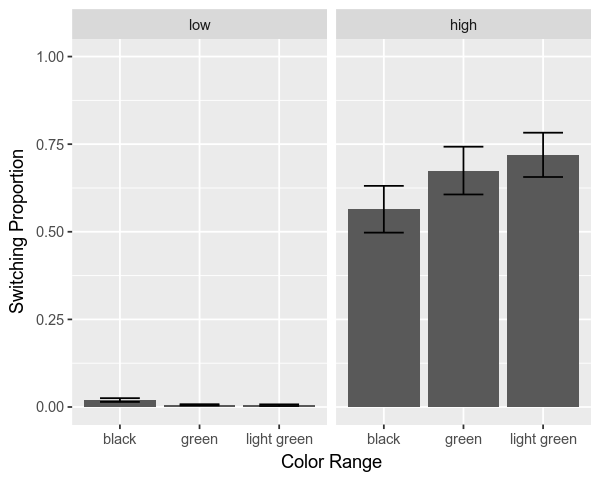

```r
options(repr.plot.width = 5, repr.plot.height = 4)
current_data %>%
group_by(subject, color, difference_d) %>%
summarize(transcode = mean(transcode)) %>%
group_by(color, difference_d) %>%
summarize(switch = mean(transcode), se = sd(transcode) / sqrt(N)) %>%
filter(difference_d != '') %>%
mutate(difference_d = factor(difference_d, levels = c('low', 'high'))) %>%
ggplot(aes(x = color, y = switch)) + geom_bar(stat = 'identity') +
geom_errorbar(stat = 'identity', aes(ymin = switch - se, ymax = switch + se), width = .5) +
ylim(0, 1) + xlab('Color Range') + ylab('Switching Proportion') + facet_wrap(~difference_d)
```

### Following up on the Difference X CTI interaction that we did not predict

Let's start by plotting the means

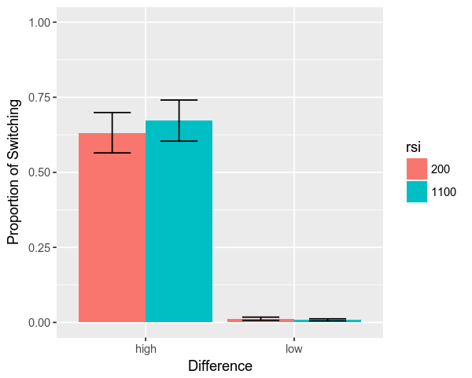

```r
diff_rsi_means %>%
ggplot(aes(x = difference_d, y = switch, group = rsi)) +
geom_bar(stat = 'identity', aes(fill = rsi), position = 'dodge') +
geom_errorbar(aes(ymin = switch - se, ymax = switch + se), position = position_dodge(width = .9), width = .5) +
ylim(0,1) + xlab('Difference') + ylab('Proportion of Switching')
```

Things just seem to be generally crused at low difference, where subjects pretty invariably repeated. Let's actually take a closer look at the numbers.

```r
diff_rsi_means
```

| rsi | difference_d | switch | se |
| --- | --- | --- | --- |
| 200 | high | 0.631861971 | 0.067203331 |
| 200 | low | 0.012328347 | 0.005396301 |
| 1100 | high | 0.672317299 | 0.068380894 |
| 1100 | low | 0.008716994 | 0.003505340 |

It's interesting to note that--at low differences--subjects are actually switching *more* with less time to prepare, which is the opposite of what's typically found in the literature. We'll test the simple effects to see whether this is significant or not.

**Simple effects:**

```r
## save omnibus terms
ssd <- m1$ANOVA$SSd[6]
dfd <- m1$ANOVA$DFd[6]
mse <- ssd / dfd

diff_low <- ezANOVA(data = current_data[current_data$difference_d == 'low',],
                    wid = subject, within = rsi, dv = transcode, detailed = TRUE)


ssn_low <- diff_low$ANOVA$SSn[2]
dfn_low <- diff_low$ANOVA$DFn[2]
msn_low <- ssn_low / dfn_low
F_low <- msn_low / mse
p_low <- pf(F_low, dfn_low, dfd, lower.tail = FALSE)
n2p_low <- ssn_low / (ssn_low + ssd)

paste0('The simple effect of cti in the low difference range: F(', dfn_low, ', ', dfd, ') = ', round(F_low, 2), ', p = ',
      round(p_low, 2), ', n2p = ', round(n2p_low, 2))
```

'The simple effect of cti in the low difference range: F(1, 15) = 0.04, p = 0.85, n2p = 0'

```r
diff_high <- ezANOVA(data = current_data[current_data$difference_d == 'high',],
                    wid = subject, within = rsi, dv = transcode, detailed = TRUE)


ssn_high <- diff_high$ANOVA$SSn[2]
dfn_high <- diff_high$ANOVA$DFn[2]
msn_high <- ssn_high / dfn_high
F_high <- msn_high / mse
p_high <- pf(F_high, dfn_high, dfd, lower.tail = FALSE)
n2p_high <- ssn_high / (ssn_high + ssd)

paste0('The simple effect of cti in the high difference range: F(', dfn_high, ', ', dfd, ') = ', round(F_high, 2), ', p = ',
      round(p_high, 4), ', n2p = ', round(n2p_high, 2))
```

'The simple effect of cti in the high difference range: F(1, 15) = 4.28, p = 0.0562, n2p = 0.22'

The simple effect of cti is marginally significant in the high difference range but not significant in the low difference range.

## Analysis 2 -- The increasing cost of effort

```r
str(current_data)
```

```
'data.frame':	12548 obs. of  15 variables:
 $ subject     : Factor w/ 16 levels "3","4","5","6",..: 1 1 1 1 1 1 1 1 1 1 ...
 $ block       : int  1 1 1 1 1 1 1 1 1 1 ...
 $ rsi         : Factor w/ 2 levels "200","1100": 2 1 1 1 1 2 2 2 2 2 ...
 $ rt          : int  1082 847 1167 633 1185 971 525 578 1317 513 ...
 $ blocktime   : num  124 124 124 124 124 ...
 $ transcode   : int  0 1 0 0 1 0 0 1 1 0 ...
 $ stimrep     : int  0 1 1 1 0 1 1 0 1 0 ...
 $ current_pv  : int  7 4 3 8 3 2 10 4 1 8 ...
 $ other_pv    : int  4 7 2 6 7 1 2 9 7 5 ...
 $ color       : Factor w/ 3 levels "black","green",..: 1 1 1 1 2 1 3 2 2 1 ...
 $ difference  : int  -3 3 -1 -2 4 -1 -8 5 6 -3 ...
 $ rt_mean     : num  666 666 666 666 666 ...
 $ rt_sd       : num  457 457 457 457 457 ...
 $ block_f     : Factor w/ 3 levels "high","low","medium": 2 2 2 2 2 2 2 2 2 2 ...
 $ difference_d: Factor w/ 3 levels "","high","low": 3 2 3 3 2 3 3 2 2 3 ...
```

**The omnibus analysis:**

```r
m2 <- ezANOVA(data = current_data, wid = subject, within = .(block_f, difference_d), dv = transcode,
              detailed = T, return_aov = TRUE, type = 2)
cbind(m2$ANOVA, n2p = m2$ANOVA$SSn / (m2$ANOVA$SSn + m2$ANOVA$SSd))
m2$"Mauchly's Test for Sphericity"
m2$"Sphericity Corrections"
```

| Effect | DFn | DFd | SSn | SSd | F | p | p<.05 | ges | n2p |
| --- | --- | --- | --- | --- | --- | --- | --- | --- | --- |
| (Intercept) | 1 | 15 | 10.2351839 | 1.3625080 | 112.680262 | 2.265747e-08 | * | 0.6804204 | 0.8825190 |
| block_f | 2 | 30 | 0.2985248 | 1.0558680 | 4.240939 | 2.387673e-02 | * | 0.0584680 | 0.2204123 |
| difference_d | 1 | 15 | 9.4001568 | 1.4108449 | 99.941780 | 5.016078e-08 | * | 0.6616374 | 0.8694992 |
| block_f:difference_d | 2 | 30 | 0.2675762 | 0.9780359 | 4.103778 | 2.658152e-02 | * | 0.0527261 | 0.2148150 |

|  | Effect | W | p | p<.05 |
| --- | --- | --- | --- | --- |
| 2 | block_f | 0.9590298 | 0.7461476 |  |
| 4 | block_f:difference_d | 0.9679415 | 0.7960561 |  |

|  | Effect | GGe | p[GG] | p[GG]<.05 | HFe | p[HF] | p[HF]<.05 |
| --- | --- | --- | --- | --- | --- | --- | --- |
| 2 | block_f | 0.9606423 | 0.02557244 | * | 1.098753 | 0.02387673 | * |
| 4 | block_f:difference_d | 0.9689373 | 0.02798457 | * | 1.110309 | 0.02658152 | * |

**Means and SEs**

```r
subject_means <- current_data %>%
group_by(subject, block_f, difference_d) %>%
summarize(transcode = mean(transcode))

N

subject_means %>%
group_by(block_f) %>%
summarize(switch = mean(transcode), se = sd(transcode) / sqrt(N))

subject_means %>%
group_by(difference_d) %>%
summarize(switch = mean(transcode), se = sd(transcode) / sqrt(N))

subject_means %>%
group_by(block_f, difference_d) %>%
summarize(switch = mean(transcode), se = sd(transcode) / sqrt(N))
```

16

| block_f | switch | se |
| --- | --- | --- |
| high | 0.2660088 | 0.09636329 |
| low | 0.4005742 | 0.10652640 |
| medium | 0.3129824 | 0.09246454 |

| difference_d | switch | se |
| --- | --- | --- |
| high | 0.63944082 | 0.084433195 |
| low | 0.01360282 | 0.004056865 |

| block_f | difference_d | switch | se |
| --- | --- | --- | --- |
| high | high | 0.522280317 | 0.102097084 |
| high | low | 0.009737341 | 0.003214540 |
| low | high | 0.783937927 | 0.061951877 |
| low | low | 0.017210569 | 0.004306022 |
| medium | high | 0.612104214 | 0.075621996 |
| medium | low | 0.013860555 | 0.004563497 |

**Simple effects:**

```r
## save omnibus terms
ssd <- m2$ANOVA$SSd[4]
dfd <- m2$ANOVA$DFd[4]
mse <- ssd / dfd

diff_low <- ezANOVA(data = current_data[current_data$difference_d == 'low',],
                    wid = subject, within = block_f, dv = transcode, detailed = TRUE)


ssn_low <- diff_low$ANOVA$SSn[2]
dfn_low <- diff_low$ANOVA$DFn[2]
msn_low <- ssn_low / dfn_low
F_low <- msn_low / mse
p_low <- pf(F_low, dfn_low, dfd, lower.tail = FALSE)
n2p_low <- ssn_low / (ssn_low + ssd)

paste0('The simple effect of block_f in the low difference range: F(', dfn_low, ', ', dfd, ') = ', round(F_low, 2), ', p = ',
      round(p_low, 2), ', n2p = ', round(n2p_low, 2))
```

'The simple effect of block_f in the low difference range: F(2, 30) = 0.01, p = 0.99, n2p = 0'

```r
diff_high <- ezANOVA(data = current_data[current_data$difference_d == 'high',],
                    wid = subject, within = block_f, dv = transcode, detailed = TRUE)


ssn_high <- diff_high$ANOVA$SSn[2]
dfn_high <- diff_high$ANOVA$DFn[2]
msn_high <- ssn_high / dfn_high
F_high <- msn_high / mse
p_high <- pf(F_high, dfn_high, dfd, lower.tail = FALSE)
n2p_high <- ssn_high / (ssn_high + ssd)

paste0('The simple effect of block_f in the high difference range: F(', dfn_high, ', ', dfd, ') = ', round(F_high, 2), ', p = ',
      round(p_high, 2), ', n2p = ', round(n2p_high, 2))
```

'The simple effect of block_f in the high difference range: F(2, 30) = 8.68, p = 0, n2p = 0.37'

```r
means_int <- lsmeans(m2$aov, specs = c('block_f', 'difference_d'))
```

```r
means_int
```

```
 block_f difference_d     lsmean         SE    df   lower.CL    upper.CL
 high    high          0.3265218 0.03076014 15.00  0.2609581  0.39208550
 low     high          0.4610872 0.05608842 44.79  0.3415376  0.58063688
 medium  high          0.3734954 0.05608842 44.79  0.2539457  0.49304502
 high    low          -0.2993162 0.06975098 21.84 -0.4479869 -0.15064547
 low     low          -0.4189351 0.12335000 66.93 -0.6818495 -0.15602083
 medium  low          -0.3380433 0.12335000 66.93 -0.6009576 -0.07512899

Confidence level used: 0.95
```

```r
contrast(means_int, list(LvM = c(0, 1, -1, 0, 0, 0),
                                LvH = c(-1, 1, 0, 0, 0, 0),
                                MvH = c(-1, 0, 1, 0, 0, 0)))
paste0('Bonferroni threshold = ', round(.05/3, 4))
```

```
 contrast   estimate         SE df t.ratio p.value
 LvM      0.08759186 0.04690123 30   1.868  0.0716
 LvH      0.13456542 0.04690123 30   2.869  0.0075
 MvH      0.04697356 0.04690123 30   1.002  0.3246
```

'Bonferroni threshold = 0.0167'

**Plot:**

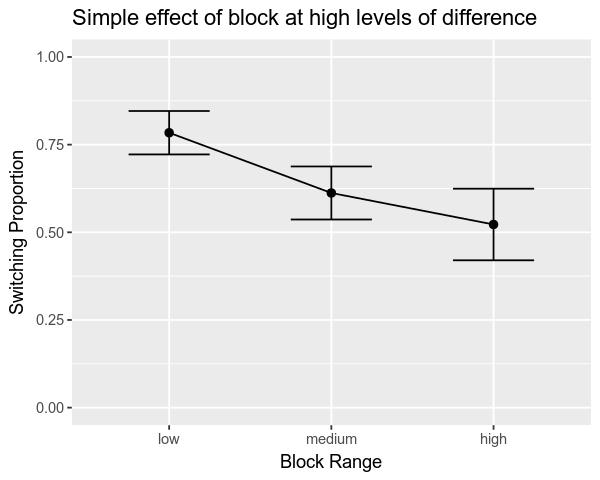

```r
options(repr.plot.width = 5, repr.plot.height = 4)
current_data %>%
mutate(block_f = factor(block_f, levels(block_f)[c(2, 3, 1)])) %>%
group_by(subject, difference_d, block_f) %>%
summarize(transcode = mean(transcode)) %>%
group_by(block_f, difference_d) %>%
summarize(switch = mean(transcode), se = sd(transcode) / sqrt(n())) %>%
filter(difference_d == 'high') %>%
ggplot(aes(x = block_f, y = switch, group = 1)) + geom_line() + geom_point(size = 2) +
geom_errorbar(stat = 'identity', aes(ymin = switch - se, ymax = switch + se), width = .5) + ylim(0, 1) +
ggtitle('Simple effect of block at high levels of difference') + xlab('Block Range') + ylab('Switching Proportion')
```